# Introducción a R

Pedro Delicado

## Índice

1. Entrar en la página web oficial de R.
2. Instalar R.
3. Instalar RStudio.
4. Crear objetos de R de distintos tipos, manejarlos y operar con ellos.
5. Leer ficheros de datos.
6. Hacer gráficos sencillos en R.
7. Exportar datos de R a otros formatos.

## 1. Entrar en la página web oficial de R

Hay (al menos) dos formas de acceder a los contenidos oficiales de R en Internet:

- [**The R Project for Statistical Computing**](http://www.r-project.org/), en [http://www.r-project.org/]. Es la página web oficial de R.
- [**CRAN: The Comprehensive R Archive Network**](https://cran.r-project.org/), en [https://cran.r-project.org/]. Es la página desde la que descargarse los ficheros de instalación de R y también los paquetes (o librerías) que complementan la instalación básica de R.

## 2. Instalar R.

Ir a [*CRAN*](https://cran.r-project.org/), descargar los ficheros de instalación e instalar R.

Aquí además hay mucha información sobre R:

- **Task Views.** Información sobre R agrupada por temas.
- **Search.** Buscar dentro de R.
- **Packages.** Librerías para realizar tareas específicas.
- **Manuals** y **Contributed.** Manuales de R a distintos niveles y en distintos idiomas. Son especialmente interesantes los siguientes:
  - *An Introduction to R* (en *Manuals*, 105 páginas). También disponible en castellano.
  - *R for Beginners* (Emmanuel Paradis, en *Contributed*, 75 páginas). También disponible en castellano.
  - *Introducción al uso y programación del sistema estadístico* (Ramón Díaz-Uriarte, en *Contributed*, slides).

## 3. Instalar RStudio.

- Ir a [https://www.rstudio.com/products/rstudio/download/], descargar los ficheros instalables e instalar [RStudio](https://www.rstudio.com/).
- Abrir RStudio y examinar los distintos marcos que aparecen: editor, consola, *environment*, gráficos, etc.
- Introducir el comando `help.start()` en la consola. Aparecen muchos de los documentos de ayuda de R que se pueden encontrar en CRAN.

## 4. Crear objetos de R de distintos tipos, manejarlos y operar con ellos.

Primeros ejemplos:

```r
x <- c(3,4,5,9)
y <- 2*x
print(x+y)
```

```
## [1]  9 12 15 27
```

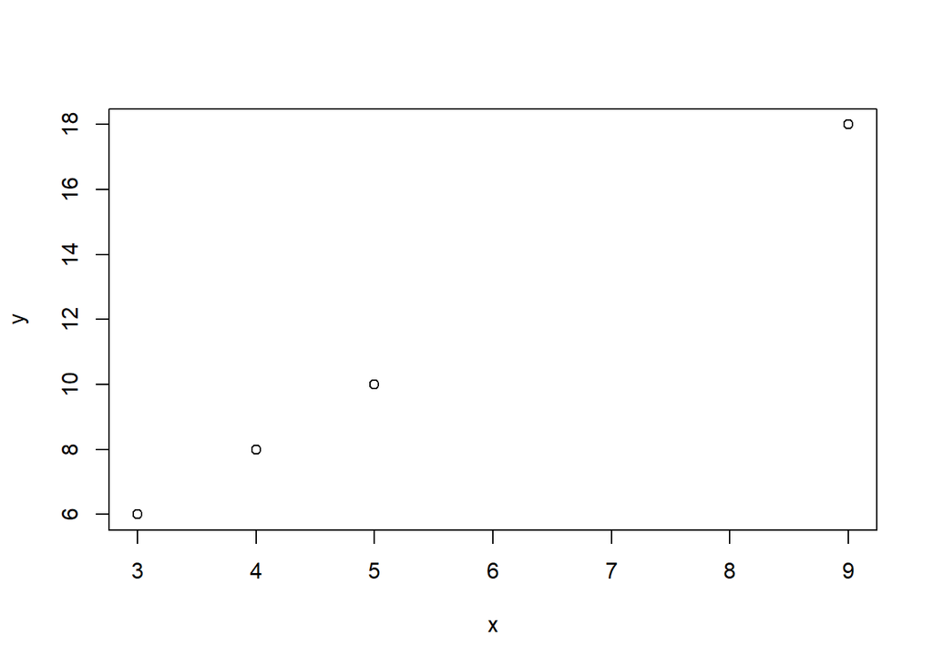

```r
plot(x,y)
```

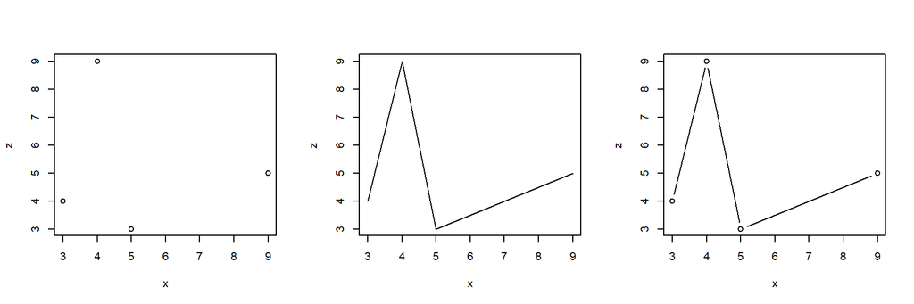

```r
z <- x[c(2,4,1,3)]
par(mfrow=c(1,3))
plot(x,z)
plot(x,z,type="l")
plot(x,z,type="b")
```

```r
par(mfrow=c(1,1))
```

```r
( A <- matrix(1:15,nrow=5,ncol=3) )
```

```
##      [,1] [,2] [,3]
## [1,]    1    6   11
## [2,]    2    7   12
## [3,]    3    8   13
## [4,]    4    9   14
## [5,]    5   10   15
```

```r
( B <- matrix(-(1:10),nrow=5) )
```

```
##      [,1] [,2]
## [1,]   -1   -6
## [2,]   -2   -7
## [3,]   -3   -8
## [4,]   -4   -9
## [5,]   -5  -10
```

```r
( C <- matrix((1:6)*100,ncol=3) )
```

```
##      [,1] [,2] [,3]
## [1,]  100  300  500
## [2,]  200  400  600
```

```r
cbind(A,B)
```

```
##      [,1] [,2] [,3] [,4] [,5]
## [1,]    1    6   11   -1   -6
## [2,]    2    7   12   -2   -7
## [3,]    3    8   13   -3   -8
## [4,]    4    9   14   -4   -9
## [5,]    5   10   15   -5  -10
```

```r
rbind(A,C)
```

```
##      [,1] [,2] [,3]
## [1,]    1    6   11
## [2,]    2    7   12
## [3,]    3    8   13
## [4,]    4    9   14
## [5,]    5   10   15
## [6,]  100  300  500
## [7,]  200  400  600
```

```r
matrix(1:4,nrow=3,nco=3)
```

```
##      [,1] [,2] [,3]
## [1,]    1    4    3
## [2,]    2    1    4
## [3,]    3    2    1
```

```r
A
```

```
##      [,1] [,2] [,3]
## [1,]    1    6   11
## [2,]    2    7   12
## [3,]    3    8   13
## [4,]    4    9   14
## [5,]    5   10   15
```

```r
C
```

```
##      [,1] [,2] [,3]
## [1,]  100  300  500
## [2,]  200  400  600
```

```r
A %*% t(C)
```

```
##       [,1]  [,2]
## [1,]  7400  9200
## [2,]  8300 10400
## [3,]  9200 11600
## [4,] 10100 12800
## [5,] 11000 14000
```

```r
(D <- matrix(round( 10 * runif(35) , 1), ncol=7))
```

```
##      [,1] [,2] [,3] [,4] [,5] [,6] [,7]
## [1,]  5.9  1.2  4.1  8.1  5.0  5.7  4.1
## [2,]  6.9  2.4  6.0  4.5  4.6  7.3  3.7
## [3,]  2.1  1.8  9.6  5.6  0.6  8.1  4.7
## [4,]  1.5  6.7  8.6  8.6  5.0  1.8  7.9
## [5,]  2.2  8.8  3.7  7.5 10.0  9.0  4.5
```

```r
dim(D)
```

```
## [1] 5 7
```

```r
(W <- D[2:5, -c(1:2,6)])
```

```
##      [,1] [,2] [,3] [,4]
## [1,]  6.0  4.5  4.6  3.7
## [2,]  9.6  5.6  0.6  4.7
## [3,]  8.6  8.6  5.0  7.9
## [4,]  3.7  7.5 10.0  4.5
```

```r
(invW <- solve(W))
```

```
##            [,1]        [,2]        [,3]        [,4]
## [1,]  0.2932890  0.07601935 -0.14421714 -0.06736555
## [2,] -0.8893917  0.51172231 -0.14464096  0.45073731
## [3,]  0.3726451 -0.17338036 -0.05120999 -0.03540891
## [4,]  0.4130705 -0.53008563  0.47344679 -0.39493071
```

```r
(W %*% invW)
```

```
##               [,1]         [,2]         [,3] [,4]
## [1,]  1.000000e+00 4.440892e-16 2.220446e-16    0
## [2,] -2.220446e-16 1.000000e+00 0.000000e+00    0
## [3,] -8.881784e-16 8.881784e-16 1.000000e+00    0
## [4,] -8.881784e-16 0.000000e+00 4.440892e-16    1
```

```r
lista <- list(1,2,3,nombre=c("Laia","Adrian"), vector= c(4,6,1,0), TF = TRUE)
lista
```

```
## [[1]]
## [1] 1
##
## [[2]]
## [1] 2
##
## [[3]]
## [1] 3
##
## $nombre
## [1] "Laia"   "Adrian"
##
## $vector
## [1] 4 6 1 0
##
## $TF
## [1] TRUE
```

```r
lista[[4]]
```

```
## [1] "Laia"   "Adrian"
```

```r
lista$nombre
```

```
## [1] "Laia"   "Adrian"
```

```r
names(lista)
```

```
## [1] ""       ""       ""       "nombre" "vector" "TF"
```

```r
str(lista)
```

```
## List of 6
##  $       : num 1
##  $       : num 2
##  $       : num 3
##  $ nombre: chr [1:2] "Laia" "Adrian"
##  $ vector: num [1:4] 4 6 1 0
##  $ TF    : logi TRUE
```

```r
class(lista)
```

```
## [1] "list"
```

```r
ll <- list(x = c(1,2,3,4), nombre=c("Laia","Adrian","Rebeca","Gerard"),
y= c(4,6,1,0), TF = c(T,T,F,F))
str(ll)
```

```
## List of 4
##  $ x     : num [1:4] 1 2 3 4
##  $ nombre: chr [1:4] "Laia" "Adrian" "Rebeca" "Gerard"
##  $ y     : num [1:4] 4 6 1 0
##  $ TF    : logi [1:4] TRUE TRUE FALSE FALSE
```

```r
class(ll)
```

```
## [1] "list"
```

```r
is.data.frame(ll)
```

```
## [1] FALSE
```

```r
as.data.frame(ll)
```

```
##   x nombre y    TF
## 1 1   Laia 4  TRUE
## 2 2 Adrian 6  TRUE
## 3 3 Rebeca 1 FALSE
## 4 4 Gerard 0 FALSE
```

```r
cbind(1:4,1:3)
```

```
##      [,1] [,2]
## [1,]    1    1
## [2,]    2    2
## [3,]    3    3
## [4,]    4    1
```

En el documento **An Introduction to R**, ir al Apéndice A **A sample session** y reproducir esa sesión en RStudio. Podéis abrir el script `A_sample_session.R`, que contiene toda esa sesión. En RStudio utilizar `Ctrl + Enter` o `Ctrl + R` para ir ejecutando línea a línea.

Puede ser de interés ir al documento **Introducción al uso y programación del sistema estadístico**, de Ramón Díaz-Uriarte, y leer las partes

- Manejo de datos en R,
- Gràficos en R,
- Introducción a la programación en R,

con el RStutio abierto, e introducir las instrucciones que vayan apareciendo en el documento.

## 5. Leer ficheros de datos y exportar datos de R a otros formatos.

Trabajaremos ahora con un conjunto de datos.

- Entrar en **Excel**, leer el fichero `presion.xls`. Este fichero contiene los valores de la presión sistólica y diastólica de 40 mujeres antes de entrar en un ensayo clínico.
- Guardarlo en formato de texto con extensión `csv`.
- Abrir el fichero `presion.csv` con un editor de textos (por ejemplo con [Notepad++](https://notepad-plus-plus.org/)) y chequear lo siguiente:
  - ¿Tiene el fichero una primera línea con los nombres de las variables?
  - ¿Cómo están separadas las columnas consecutivas? ¿Por espacios en blanco? ¿Por algún carácter como “,” o “;”? ¿Por tabuladores?
  - ¿El punto decimal es un punto o una coma?
- Entrar en RStudio.
- Leer los datos del fichero `presion.csv` como un `data.frame`. Utilizar la función `read.table` o una de sus versiones preparadas para ficheros `csv`: `read.csv` o `read.csv2`.

```r
# help(read.table)
presion <- read.csv2("presion.csv")

class(presion)
```

```
## [1] "data.frame"
```

```r
names(presion)
```

```
## [1] "PresSis" "PresDia"
```

```r
head(presion)
```

```
##   PresSis PresDia
## 1     120      85
## 2     121      86
## 3     127      78
## 4     138      83
## 5     119      80
## 6     110      65
```

```r
tail(presion)
```

```
##    PresSis PresDia
## 35     110      60
## 36     115      60
## 37     100      50
## 38     120      70
## 39     110      60
## 40     120      80
```

## 6. Hacer gráficos sencillos en R.

- Hacer una descripción estadística gráfica y numérica sencilla de las dos variables recién leídas: `PresSis` y `PresDia`.

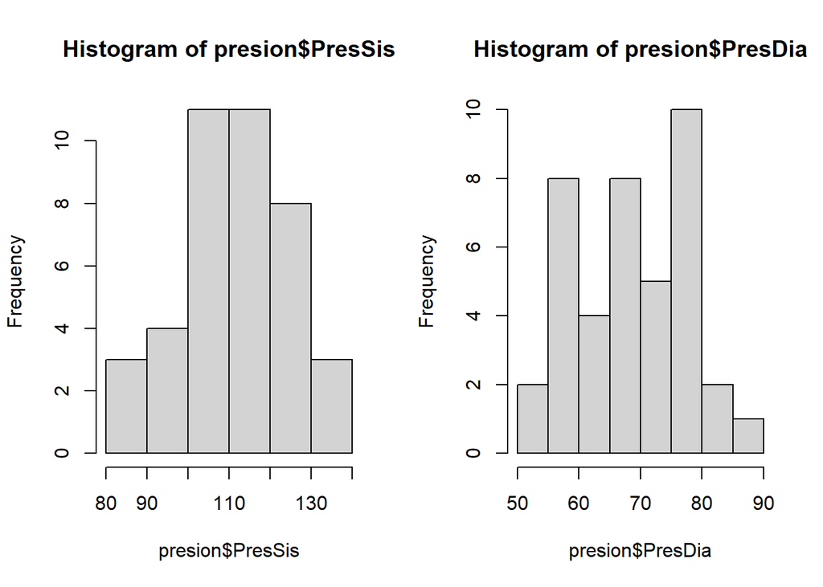

```r
par(mfrow=c(1,2))
hist(presion$PresSis)
hist(presion$PresDia)
```

```r
par(mfrow=c(1,2))
```

- Hacer un gráfico de dispersión de una variable frente a otra.

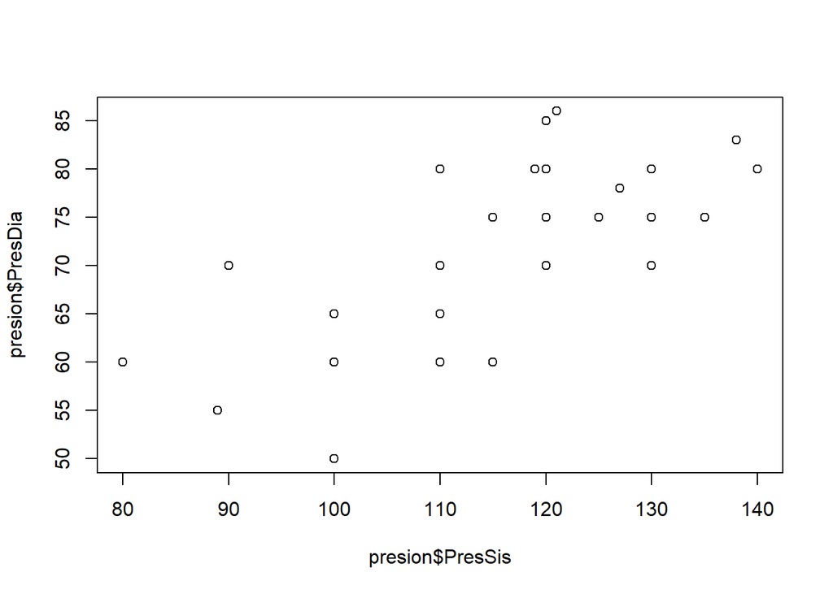

```r
plot(presion$PresSis, presion$PresDia)
```

## 7. Exportar datos de R a otros formatos.

- Dividir cada una de las variables `PresSis` y `PresDia` por su mediana.

```r
PresSis_relativa <- presion$PresSis/median(presion$PresSis)
PresDia_relativa <- presion$PresDia/median(presion$PresDia)
```

- Añadir al data.frame `presion` las variables que acabamos de crear.

```r
presion$PresSisRel <- PresSis_relativa
presion$PresDiaRel <- PresDia_relativa

names(presion)
```

```
## [1] "PresSis"    "PresDia"    "PresSisRel" "PresDiaRel"
```

```r
head(presion)
```

```
##   PresSis PresDia PresSisRel PresDiaRel
## 1     120      85  1.0256410  1.2142857
## 2     121      86  1.0341880  1.2285714
## 3     127      78  1.0854701  1.1142857
## 4     138      83  1.1794872  1.1857143
## 5     119      80  1.0170940  1.1428571
## 6     110      65  0.9401709  0.9285714
```

- Escribir en un fichero de texto ese `data.frame`. Leerlo después desde el programa **Excel**.

```r
write.csv2(presion,file="presion_new.csv", row.names = FALSE)
```

- Guardar el data.frame `presion` en un fichero de datos en un formato propio de R, con extensión `Rdata`.

```r
save(presion,file="presion.Rdata")
```

- También se puede guardar todos los elementos del entorno de trabajo (*Environment*):

```r
save.image(file="todo.Rdata")
```

- Borrar ahora todos los objetos del *Environment*:

```r
rm(list=ls())
ls()
```

```
## character(0)
```

- Recuperar ahora el data frame `presion`que hemos guardado en `presion.Rdata`:

```r
load(file="presion.Rdata")
ls()
```

```
## [1] "presion"
```

- También podmos recuperar un entorno de trabajo completo que hayamos guardado con `save.image`:

```r
load(file="todo.Rdata")
ls()
```

```
##  [1] "A"                "B"                "C"                "D"
##  [5] "invW"             "lista"            "ll"               "PresDia_relativa"
##  [9] "presion"          "PresSis_relativa" "W"                "x"
## [13] "y"                "z"
```